# Does International Collaboration Help IMDB Ratings? (focusing on Netflix)

# 2 Which countries are producing content on Netflix?

## 2.1 Where do the movies/shows come from? (rank)

*caveat: data is based on titles that are available on Netflix as of mid-2021 - movies/shows on Netflix were produced by 122 different countries

- number_of_countries 1 7487  
  2 873  
  3 273  
  4 114  
  5 37 6+ 23 (max number 12)

6 14  
7 5  
8 2  
9 0 10 1  
11 0 12 1

```r
# sum(is.na(netflix$country)) # check the number of NAs (missing country data) N=831

# Extract country data

temp=netflix %>% mutate(country1=str_split_i(country,",",1),
                           country2=str_split_i(country,",",2),
                           country3=str_split_i(country,",",3),
                           country4=str_split_i(country,",",4),
                           country5=str_split_i(country,",",5),
                           country6=str_split_i(country,",",6),
                           country7=str_split_i(country,",",7),
                           country8=str_split_i(country,",",8),
                           country9=str_split_i(country,",",9),
                        country10=str_split_i(country,",",10),
                        country11=str_split_i(country,",",11),
                        country12=str_split_i(country,",",12)) %>%
  select(Title,country1,country2,country3,country4,country5,country6,country7,country8,country9,country10,country11, country12,year_added_to_netflix,Genre)

netflix_long_df<-melt(temp,id=c("Title","year_added_to_netflix","Genre"),na.rm=T) %>% arrange(Title)
netflix_long_df = netflix_long_df %>% mutate(country=str_trim(value,side=c("left")))

# Data engineering
netflix_long_df[459,]['country']<-"United States"
netflix_long_df[2639,]['country']<-"United Kingdom"
# which(netflix_long_df['country']=='')
netflix_long_df<-netflix_long_df[-c(1748,1990,2620,2934,3571,8661,9548),] # remove blanks

# Rank which country produced most shows/movies on Neflix
# unique(netflix_long_df$country) # movies/shows on Netflix were produced by 122 different countries
country_count=netflix_long_df %>% count(country) %>% arrange(desc(n)) %>%
  mutate(perc=round(`n`/sum(`n`),3)) %>% mutate(percentage = scales::percent(perc))

# netflix_long_df %>% group_by(country) %>% count()  %>%
#   ungroup() %>%
#  mutate(perc=round(`n`/sum(`n`),2)) %>%  mutate(percentage = scales::percent(perc)) %>% arrange(desc(perc))

plot_df=temp%>%
  mutate(number_of_countries=ifelse(is.na(country2),1,
                              ifelse(is.na(country3),2,
                                     ifelse(is.na(country4),3,
                                            ifelse(is.na(country5),4,
                                                   ifelse(is.na(country6),5,6
                                                        ))))))
```

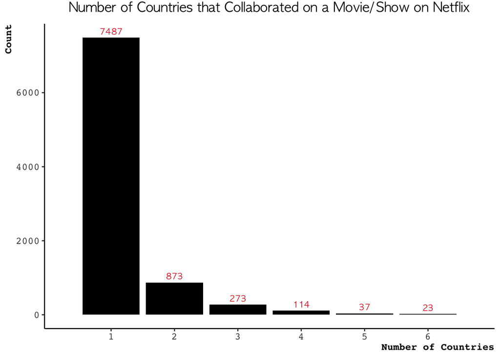

```r
plot_df=plot_df %>% count(number_of_countries)

ggplot(plot_df, aes(x=number_of_countries,y=n,fill=n))+ geom_col(fill = "black") +
  geom_text(aes(label=n,fontface="bold"), vjust = -0.5, size =3,color="#E50914",family = 'AppleGothic') + theme_bw() +theme_classic()+
  xlab(c("Number of Countries"))+ylab(c("Count"))+
  scale_x_discrete(limits=c(seq(1,6,1)))+
  ggtitle("Number of Countries that Collaborated on a Movie/Show on Netflix")+
  theme(plot.title = element_text(hjust = 0.5,vjust=2.5,face="bold",family = 'AppleGothic'),
        axis.text.x = element_text(size=10, family = 'mono'),
        axis.text.y = element_text(size=10, family = 'mono'),
        axis.title.x = element_text(size=10,face="bold", family = 'mono',hjust=1),
        axis.title.y = element_text(size=10, face="bold",family = 'mono',vjust=1,hjust=1))
```

```r
country_count=country_count %>% mutate("Production Country"=country, "Number of Movies/Shows"=n,"Percentage (%)"=perc*100 )

# plot distribution of countries in table
formattable(country_count %>% select("Production Country", "Number of Movies/Shows", "Percentage (%)"), align=c("r","r","r"),
            list(`Number of Movies/Shows`=color_bar("#E50914"),`Percentage (%)`=color_bar("gray")))
```

| Production Country | Number of Movies/Shows | Percentage (%) |
| --- | --- | --- |
| United States | 3691 | 36.9 |
| India | 1046 | 10.4 |
| United Kingdom | 807 | 8.1 |
| Canada | 445 | 4.4 |
| France | 393 | 3.9 |
| Japan | 318 | 3.2 |
| Spain | 232 | 2.3 |
| South Korea | 231 | 2.3 |
| Germany | 226 | 2.3 |
| Mexico | 169 | 1.7 |
| China | 162 | 1.6 |
| Australia | 160 | 1.6 |
| Egypt | 116 | 1.2 |
| Turkey | 113 | 1.1 |
| Hong Kong | 105 | 1.0 |
| Nigeria | 103 | 1.0 |
| Italy | 100 | 1.0 |
| Brazil | 97 | 1.0 |
| Argentina | 91 | 0.9 |
| Belgium | 90 | 0.9 |
| Indonesia | 90 | 0.9 |
| Taiwan | 89 | 0.9 |
| Philippines | 83 | 0.8 |
| Thailand | 70 | 0.7 |
| South Africa | 62 | 0.6 |
| Colombia | 52 | 0.5 |
| Netherlands | 50 | 0.5 |
| Denmark | 48 | 0.5 |
| Ireland | 46 | 0.5 |
| Sweden | 42 | 0.4 |

[output cut: 92 more lines]

## 2.2 Is international collaboration associated with higher IMDB ratings?

- When more countries are included in production, the movie/show is more likely to get higher ratings on IMDB.

```r
# Data preparation

# extract country information
temp=netflix_ratings %>% mutate(country1=str_split_i(country,",",1),
                           country2=str_split_i(country,",",2),
                           country3=str_split_i(country,",",3),
                           country4=str_split_i(country,",",4),
                           country5=str_split_i(country,",",5),
                           country6=str_split_i(country,",",6),
                           country7=str_split_i(country,",",7),
                           country8=str_split_i(country,",",8),country9=str_split_i(country,",",9))


# sum(is.na(temp$country)) # 118 titles have no country information

# sum(is.na(temp$country1)==FALSE) # 1799 movies/shows have 1 country involved
# sum(is.na(temp$country2)==FALSE) # 318 movies/shows have 2 countries involved
# sum(is.na(temp$country3)==FALSE) # 115 movies/shows have 3 countries involved
# sum(is.na(temp$country4)==FALSE) # 49 movies/shows have 4 countries involved
# sum(is.na(temp$country5)==FALSE) # 13 movies/shows have 5 countries involved
# sum(is.na(temp$country6)==FALSE) # 3 movies/shows have 6 countries involved
# sum(is.na(temp$country7)==FALSE) # 4 movies/shows have 7 countries involved
# sum(is.na(temp$country8)==FALSE) # 1 movies/shows have 8 countries involved
# sum(is.na(temp$country9)==FALSE) # 1 movies/shows have 12 countries involved (max number)


temp=temp %>%
  select(Title,country,country1,country2,country3,country4,country5,country6,country7,country8,country9,
         year_added_to_netflix,Genre,averageRating,numVotes)

nf_df_cleaned=temp%>%
  mutate(number_of_countries=ifelse(is.na(country2),1,
                              ifelse(is.na(country3),2,
                                     ifelse(is.na(country4),3,
                                            ifelse(is.na(country5),4,
                                                   ifelse(is.na(country6),5,6)))))) # 6 means 6 or more countries

# U.S. vs. other countries (binary coding: other 0 vs. U.S. 1) (collab 1 vs. single country 0)
nf_df_cleaned=nf_df_cleaned %>% mutate(collab_or_not = ifelse(number_of_countries>=2,1,0),
                                      us_or_not=ifelse(grepl('United States',country),1,0))
```

```r
# when multiple countries are involved in producing a show/movie, it is more likely to get higher ratings on IMDB; highly likely to get more viewers

nf_df_cleaned %>%
    summarise( # summarise operation by group
        Mean_Rating= mean(averageRating),
        Standard_Deviation= sd(averageRating),
        Max_Rating=max(averageRating),
        Min_Rating=min(averageRating)
    )
```

```
##   Mean_Rating Standard_Deviation Max_Rating Min_Rating
## 1    6.594415           1.031551          9        2.5
```

```r
nf_df_cleaned[which(nf_df_cleaned$averageRating==max(nf_df_cleaned$averageRating))[1],] # highest rating
```

```
##         Title                  country  country1       country2 country3
## 602 Reckoning Australia, United States Australia  United States     <NA>
##     country4 country5 country6 country7 country8 country9 year_added_to_netflix
## 602     <NA>     <NA>     <NA>     <NA>     <NA>     <NA>                  2020
##                                       Genre averageRating numVotes
## 602 Crime TV Shows, TV Dramas, TV Mysteries             9      483
##     number_of_countries collab_or_not us_or_not
## 602                   2             1         1
```

```r
nf_df_cleaned[which(nf_df_cleaned$averageRating==max(nf_df_cleaned$averageRating))[2],] # highest rating
```

```
##                Title       country      country1 country2 country3 country4
## 635 Schindler's List United States United States     <NA>     <NA>     <NA>
##     country5 country6 country7 country8 country9 year_added_to_netflix
## 635     <NA>     <NA>     <NA>     <NA>     <NA>                  2018
##                      Genre averageRating numVotes number_of_countries
## 635 Classic Movies, Dramas             9  1367478                   1
##     collab_or_not us_or_not
## 635             0         1
```

```r
nf_df_cleaned[which(nf_df_cleaned$averageRating==max(nf_df_cleaned$averageRating))[3],] # highest rating
```

```
##                                             Title                    country
## 786 The Lord of the Rings: The Return of the King New Zealand, United States
##        country1       country2 country3 country4 country5 country6 country7
## 786 New Zealand  United States     <NA>     <NA>     <NA>     <NA>     <NA>
##     country8 country9 year_added_to_netflix
## 786     <NA>     <NA>                  2020
##                                    Genre averageRating numVotes
## 786 Action & Adventure, Sci-Fi & Fantasy             9  1862791
##     number_of_countries collab_or_not us_or_not
## 786                   2             1         1
```

```r
nf_df_cleaned[which(nf_df_cleaned$averageRating==min(nf_df_cleaned$averageRating))[1],] # lowest rating
```

```
##                Title       country      country1 country2 country3 country4
## 77 Battlefield Earth United States United States     <NA>     <NA>     <NA>
##    country5 country6 country7 country8 country9 year_added_to_netflix
## 77     <NA>     <NA>     <NA>     <NA>     <NA>                  2021
##                                                Genre averageRating numVotes
## 77 Action & Adventure, Cult Movies, Sci-Fi & Fantasy           2.5    80943
##    number_of_countries collab_or_not us_or_not
## 77                   1             0         1
```

### 2.2.1 Average Ratings

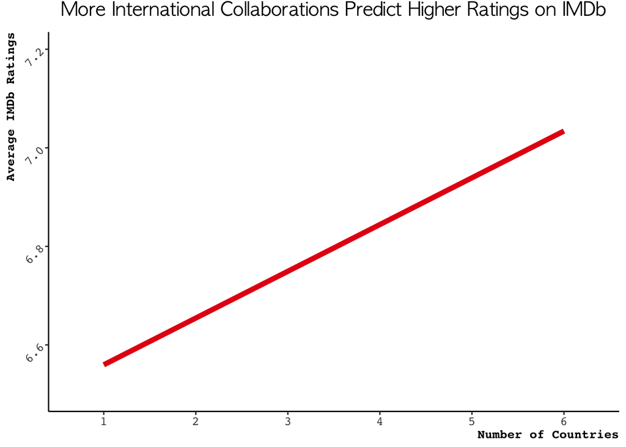

```r
ggplot(data=nf_df_cleaned,aes(x=number_of_countries,y=averageRating))+
  geom_smooth(method=lm,colour="#E50914",size=2,se=FALSE)+
  scale_x_discrete(limits=c(seq(1,6,1))) +  coord_cartesian(ylim=c(6.5,7.2))+
  theme_bw()+theme_classic()+
  labs(x="Number of Countries", y="Average IMDb Ratings", title="More International Collaborations Predict Higher Ratings on IMDb")+
  theme(plot.title = element_text(hjust = 0.5,vjust=2.5,size=15,face="bold",family = 'AppleGothic'),
        axis.text.x = element_text(size=10, family = 'mono'),
        axis.text.y = element_text(size=10, family = 'mono',angle=45),
        axis.title.x = element_text(size=10,face="bold", family = 'mono',hjust=1),
        axis.title.y = element_text(size=10, face="bold",family = 'mono',vjust=1,hjust=1))
```

```r
summary(lm(numVotes~number_of_countries,data=nf_df_cleaned)) # proxy for the number of viewers
```

```
##
## Call:
## lm(formula = numVotes ~ number_of_countries, data = nf_df_cleaned)
##
## Residuals:
##     Min      1Q  Median      3Q     Max
## -263368  -84630  -72280   11300 1991989
##
## Coefficients:
##                     Estimate Std. Error t value  Pr(>|t|)
## (Intercept)            49679      13220   3.758  0.000182 ***
## number_of_countries    35739       8404   4.253 0.0000233 ***
## ---
## Signif. codes:  0 '***' 0.001 '**' 0.01 '*' 0.05 '.' 0.1 ' ' 1
##
## Residual standard error: 199900 on 929 degrees of freedom
## Multiple R-squared:  0.0191, Adjusted R-squared:  0.01804
## F-statistic: 18.09 on 1 and 929 DF,  p-value: 0.00002326
```

```r
cor.test(nf_df_cleaned$numVotes,nf_df_cleaned$averageRating) # titles that have more votes tend to score higher on ratings
```

```
##
##  Pearson's product-moment correlation
##
## data:  nf_df_cleaned$numVotes and nf_df_cleaned$averageRating
## t = 11.578, df = 929, p-value < 0.00000000000000022
## alternative hypothesis: true correlation is not equal to 0
## 95 percent confidence interval:
##  0.2976585 0.4100126
## sample estimates:
##       cor
## 0.3551173
```

### 2.2.2 Number of Votes

[figure not shown]

```r
ggplot(data=nf_df_cleaned,aes(x=number_of_countries,y=numVotes))+
  geom_smooth(method=lm,colour="#E50914",size=2,se=FALSE)+
  scale_x_discrete(limits=c(seq(1,6,1)))+  theme_bw()+theme_classic()+
  labs(x="Number of Countries", y="Number of Votes", title="More International Collaborations Predict More Votes on IMDb")+
  theme(plot.title = element_text(hjust = 0.5,vjust=2.5,size=15,face="bold",family = 'AppleGothic'),
        axis.text.x = element_text(size=10, family = 'mono'),
        axis.text.y = element_text(size=10, family = 'mono',angle=45),
        axis.title.x = element_text(size=10,face="bold", family = 'mono',hjust=1),
        axis.title.y = element_text(size=10, face="bold",family = 'mono',vjust=1,hjust=1))
```

```r
summary(lm(numVotes~number_of_countries,data=nf_df_cleaned)) # proxy for the number of viewers
```

```
##
## Call:
## lm(formula = numVotes ~ number_of_countries, data = nf_df_cleaned)
##
## Residuals:
##     Min      1Q  Median      3Q     Max
## -263368  -84630  -72280   11300 1991989
##
## Coefficients:
##                     Estimate Std. Error t value  Pr(>|t|)
## (Intercept)            49679      13220   3.758  0.000182 ***
## number_of_countries    35739       8404   4.253 0.0000233 ***
## ---
## Signif. codes:  0 '***' 0.001 '**' 0.01 '*' 0.05 '.' 0.1 ' ' 1
##
## Residual standard error: 199900 on 929 degrees of freedom
## Multiple R-squared:  0.0191, Adjusted R-squared:  0.01804
## F-statistic: 18.09 on 1 and 929 DF,  p-value: 0.00002326
```

```r
summary(lm(averageRating~number_of_countries,data=nf_df_cleaned)) # proxy for the number of viewers
```

```
##
## Call:
## lm(formula = averageRating ~ number_of_countries, data = nf_df_cleaned)
##
## Residuals:
##     Min      1Q  Median      3Q     Max
## -4.0597 -0.6468  0.0403  0.7403  2.4403
##
## Coefficients:
##                     Estimate Std. Error t value            Pr(>|t|)
## (Intercept)          6.46480    0.06806  94.980 <0.0000000000000002 ***
## number_of_countries  0.09487    0.04327   2.193              0.0286 *
## ---
## Signif. codes:  0 '***' 0.001 '**' 0.01 '*' 0.05 '.' 0.1 ' ' 1
##
## Residual standard error: 1.029 on 929 degrees of freedom
## Multiple R-squared:  0.005148,   Adjusted R-squared:  0.004077
## F-statistic: 4.808 on 1 and 929 DF,  p-value: 0.02858
```

```r
cor.test(nf_df_cleaned$numVotes,nf_df_cleaned$averageRating) # titles that have more votes tend to score higher on ratings
```

```
##
##  Pearson's product-moment correlation
##
## data:  nf_df_cleaned$numVotes and nf_df_cleaned$averageRating
## t = 11.578, df = 929, p-value < 0.00000000000000022
## alternative hypothesis: true correlation is not equal to 0
## 95 percent confidence interval:
##  0.2976585 0.4100126
## sample estimates:
##       cor
## 0.3551173
```

# 3 How about Netflix Originals, specifically?

- Out of 504 movies …
- Netflix original movies were produced by 43 different countries
- 430 movies/shows have 1 country involved
- 59 movies/shows have 2 countries involved
- 14 movies/shows have 3 countries involved
- 1 movies/shows have 4 countries involved

## 3.1 Where did the movies come from?

- more prominent dominance of U.S

```r
# Data Preparation
# Extract country data
temp=netflix_originals %>% mutate(country1=str_split_i(country,",",1),
                           country2=str_split_i(country,",",2),
                           country3=str_split_i(country,",",3),
                           country4=str_split_i(country,",",4))
temp=temp %>% distinct(Title,Genre,Language,.keep_all=TRUE) # remove duplicates


temp1=temp %>%
  select(Title,country1,country2,country3,country4,premiere_year,IMDB.Score,Genre)

netflix_originals_long_df<-melt(temp1,id=c("Title","premiere_year","IMDB.Score","Genre"),na.rm=T) %>% arrange(Title)
netflix_originals_long_df = netflix_originals_long_df %>% mutate(country=str_trim(value,side=c("left")))

# Rank which country produced most Netflix Original movies
# unique(netflix_originals_long_df$country) # Netflix original movies were produced by 43 different countries

country_count=netflix_originals_long_df %>% count(country) %>% arrange(desc(n)) %>%
  mutate(perc=round(`n`/sum(`n`),3)) %>% mutate(percentage = scales::percent(perc))

# plot table
formattable(country_count %>% select(country,n,percentage), list(`n`=color_bar(color="lightblue")))
```

| country | n | percentage |
| --- | --- | --- |
| United States | 327 | 56.4% |
| India | 38 | 6.6% |
| United Kingdom | 38 | 6.6% |
| Canada | 17 | 2.9% |
| France | 16 | 2.8% |
| Italy | 16 | 2.8% |
| Spain | 14 | 2.4% |
| Mexico | 11 | 1.9% |
| Indonesia | 9 | 1.6% |
| Brazil | 8 | 1.4% |
| Germany | 8 | 1.4% |
| South Korea | 8 | 1.4% |
| Japan | 7 | 1.2% |
| Argentina | 6 | 1.0% |
| Hungary | 4 | 0.7% |
| South Africa | 4 | 0.7% |
| Turkey | 4 | 0.7% |
| Australia | 3 | 0.5% |
| Belgium | 3 | 0.5% |
| Netherlands | 3 | 0.5% |
| Philippines | 3 | 0.5% |
| Poland | 3 | 0.5% |
| Thailand | 3 | 0.5% |
| Austria | 2 | 0.3% |
| China | 2 | 0.3% |
| Denmark | 2 | 0.3% |
| Ireland | 2 | 0.3% |
| Nigeria | 2 | 0.3% |
| Norway | 2 | 0.3% |
| Sweden | 2 | 0.3% |
|  | 1 | 0.2% |
| Albania | 1 | 0.2% |
| Cambodia | 1 | 0.2% |
| Chile | 1 | 0.2% |
| Greece | 1 | 0.2% |
| Iceland | 1 | 0.2% |
| Iran | 1 | 0.2% |
| Israel | 1 | 0.2% |
| Malaysia | 1 | 0.2% |
| Pakistan | 1 | 0.2% |
| Switzerland | 1 | 0.2% |
| Ukraine | 1 | 0.2% |
| United Arab Emirates | 1 | 0.2% |

```r
nf_originals_df_cleaned=temp%>%
  mutate(number_of_countries=ifelse(is.na(country2),1,
                              ifelse(is.na(country3),2,
                                     ifelse(is.na(country4),3,4)))) # 6 means 6 or more countries

# U.S. vs. other countries (binary coding: other 0 vs. U.S. 1) (collab 1 vs. single country 0)
nf_originals_df_cleaned=nf_originals_df_cleaned %>% mutate(collab_or_not = ifelse(number_of_countries>=2,1,0),
                                      us_or_not=ifelse(grepl('United States',country),1,0))

originals_country_count=netflix_originals_long_df %>% count(country) %>%
  arrange(desc(n)) %>%mutate(perc=round(`n`/sum(`n`),3)) %>% mutate(percentage = scales::percent(perc))

originals_country_count=originals_country_count %>% mutate("Production Country"=country,
                                                           "Number of Movies/Shows"=n,"Percentage (%)"=perc*100 )
```

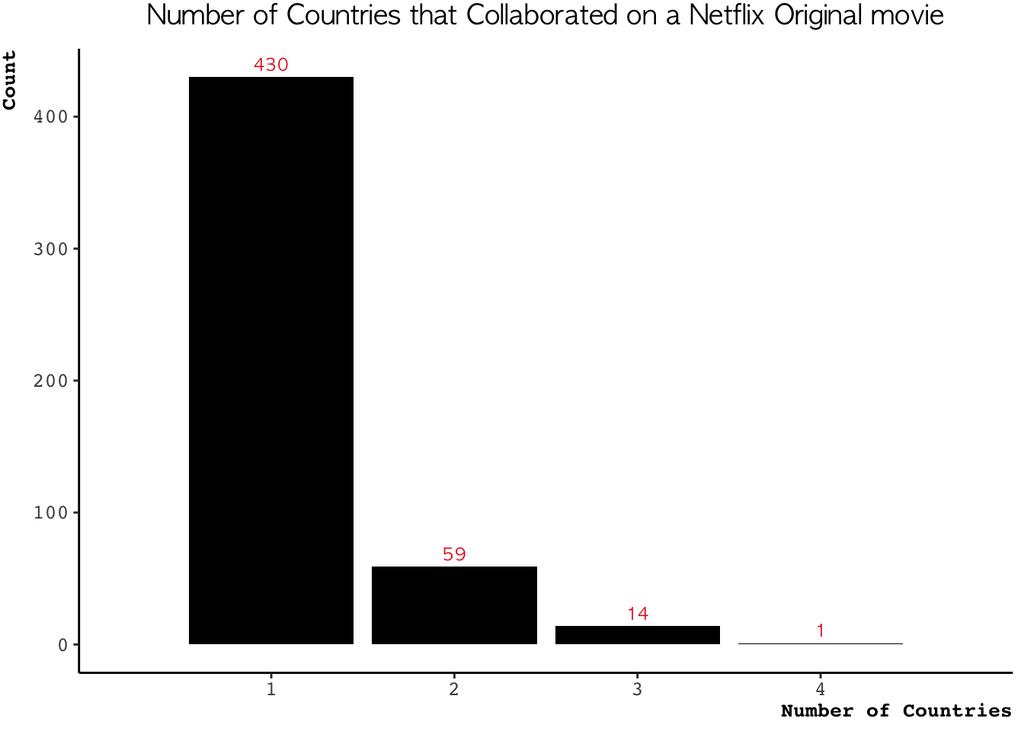

```r
plot_originals_df<-nf_originals_df_cleaned %>% count(number_of_countries)

ggplot(plot_originals_df, aes(x=number_of_countries,y=n,fill=n))+ geom_col(fill = "black") +
  geom_text(aes(label=n,fontface="bold"), vjust = -0.5, size =3,color="#E50914",family = 'AppleGothic') + theme_bw() +theme_classic()+
  xlab(c("Number of Countries"))+ylab(c("Count"))+
  scale_x_discrete(limits=c(seq(1,4,1)))+
  ggtitle("Number of Countries that Collaborated on a Netflix Original movie")+
  theme(plot.title = element_text(hjust = 0.5,vjust=2.5,face="bold",family = 'AppleGothic'),
        axis.text.x = element_text(size=10, family = 'mono'),
        axis.text.y = element_text(size=10, family = 'mono'),
        axis.title.x = element_text(size=10,face="bold", family = 'mono',hjust=1),
        axis.title.y = element_text(size=10, face="bold",family = 'mono',vjust=3,hjust=1))
```

```r
# plot distribution of countries in table
formattable(originals_country_count %>% select("Production Country", "Number of Movies/Shows", "Percentage (%)"), align=c("r","r","r"),
            list(`Number of Movies/Shows`=color_bar("#E50914"),`Percentage (%)`=color_bar("gray")))
```

| Production Country | Number of Movies/Shows | Percentage (%) |
| --- | --- | --- |
| United States | 327 | 56.4 |
| India | 38 | 6.6 |
| United Kingdom | 38 | 6.6 |
| Canada | 17 | 2.9 |
| France | 16 | 2.8 |
| Italy | 16 | 2.8 |
| Spain | 14 | 2.4 |
| Mexico | 11 | 1.9 |
| Indonesia | 9 | 1.6 |
| Brazil | 8 | 1.4 |
| Germany | 8 | 1.4 |
| South Korea | 8 | 1.4 |
| Japan | 7 | 1.2 |
| Argentina | 6 | 1.0 |
| Hungary | 4 | 0.7 |
| South Africa | 4 | 0.7 |
| Turkey | 4 | 0.7 |
| Australia | 3 | 0.5 |
| Belgium | 3 | 0.5 |
| Netherlands | 3 | 0.5 |
| Philippines | 3 | 0.5 |
| Poland | 3 | 0.5 |
| Thailand | 3 | 0.5 |
| Austria | 2 | 0.3 |
| China | 2 | 0.3 |
| Denmark | 2 | 0.3 |
| Ireland | 2 | 0.3 |
| Nigeria | 2 | 0.3 |
| Norway | 2 | 0.3 |
| Sweden | 2 | 0.3 |
|  | 1 | 0.2 |
| Albania | 1 | 0.2 |
| Cambodia | 1 | 0.2 |
| Chile | 1 | 0.2 |
| Greece | 1 | 0.2 |
| Iceland | 1 | 0.2 |
| Iran | 1 | 0.2 |
| Israel | 1 | 0.2 |
| Malaysia | 1 | 0.2 |
| Pakistan | 1 | 0.2 |
| Switzerland | 1 | 0.2 |
| Ukraine | 1 | 0.2 |
| United Arab Emirates | 1 | 0.2 |